# International Ramen Rankings

## Data Visualisation

- Now the data has been processed and transformed into more usable variables it is time to visualise it. This was achieved utilising the ggplot function.

#### Initial Plot

- The initial plot i utlised was a grouped bar graph aiming to represent the Country (x-axis), the style of ramen (group fill), and their respective star ratings (y-axis.)

```r
InitialPlot <- ggplot(MeanTibbleGrouped, aes(fill=Style, y=Stars, x=Country)) +
    geom_bar(position="dodge", stat="identity")
```

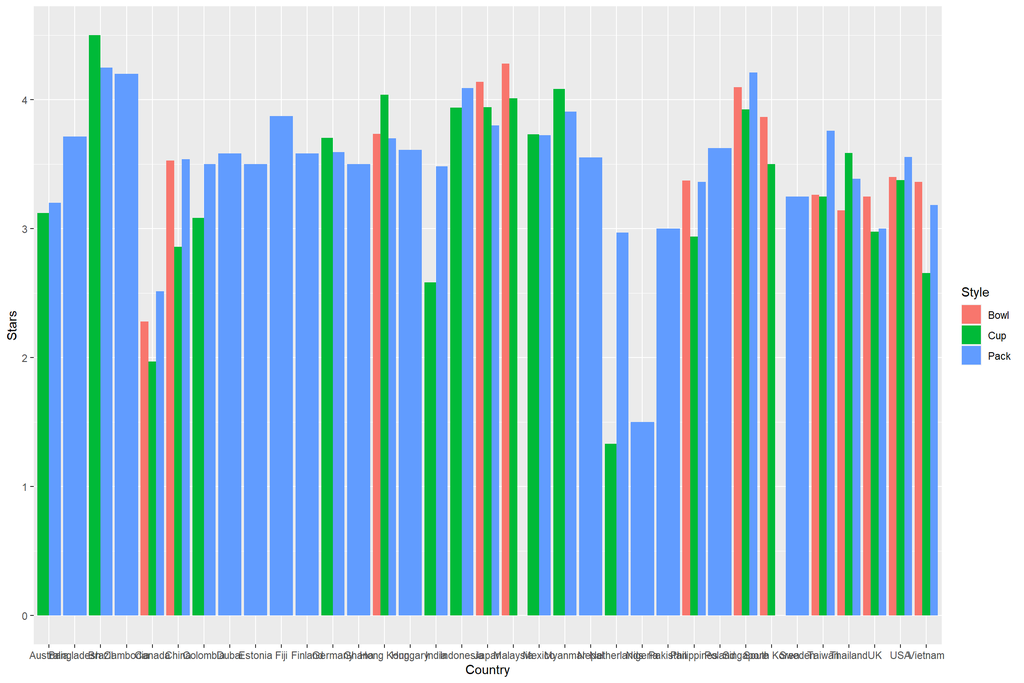

```r
library(knitr)
plot(InitialPlot)
```

- As you can see this visualisation was less than ideal as there are far too many countries along the x-axis to provide a clear representation.

#### Final Plot

- I chose to utilise subplots in order to better represent the individual country ratings. This was achieved by changing the axes. Now having Style (x-axis), Star rating (y-axis); and splitting the plots by country. A header was generated via the ggplot Tile function. The plot separation was made possible by using the facet_wrap function.

```r
FinalPlot <- ggplot(MeanTibbleGrouped, aes(fill=Country, y=Stars, x=Style)) +
    geom_bar(position="dodge", stat="identity") +
    scale_fill_viridis(discrete = T, option = "E") +
    ggtitle("Ramen Style Ratings Across Countries") +
    facet_wrap(~Country) +
    theme_ipsum() +
    theme(legend.position="none") +
    xlab("")
```

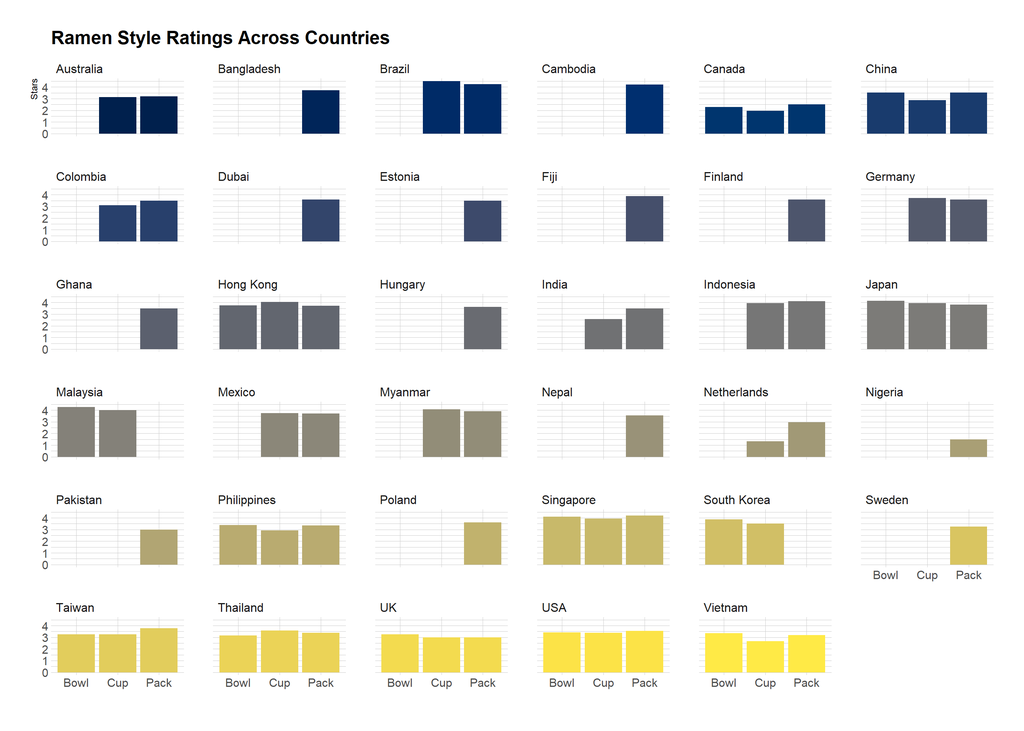

```r
plot(FinalPlot)
```

## Reflection

- There are limitations to the inferences that can be drawn from this visualization. The data set shows a number of missing cases in regards to many countries style rankings. For Instance Nepal shows a ranking of 0 for both bowl and cup styles. It is unexplained in the data set whether this is actually representative of a rank score of 0. This could in fact be due to a failing in data collection, or perhaps an inaccessibility of certain styles in Nepal’s general market. Further data collection should be conducted for the countries showing these deficits to determine whether this is a preferential deficit or a possible gap in the market.
- Given more time for the analysis i would have liked to adapt my visualisation into a more efficient representation such as a circular bar graph grouped by geographical region to make my summary inferences more easily inferable. However given the time restraints i was unable to do so.

## Resources

- Complete analysis of Ramen Ratings. (2022). Retrieved 16 May 2022, from https://www.kaggle.com/code/sujan97/complete-analysis-of-ramen-ratings/data
- The Instant Ramen Boom Is Now Worth Tens of Billions of Dollars. (2022). Retrieved 16 May 2022, from https://marker.medium.com/the-instant-ramen-boom-is-now-worth-tens-of-billions-of-dollars-89a5466620bc
- World Map / World Atlas / Atlas of the World Including Geography Facts and Flags - WorldAtlas.com. (2022). Retrieved 16 May 2022, from https://www.worldatlas.com/